# HSC Survey Results

# Scots Bay Survey # 1 Results from 22/05/2023

## Survey Details

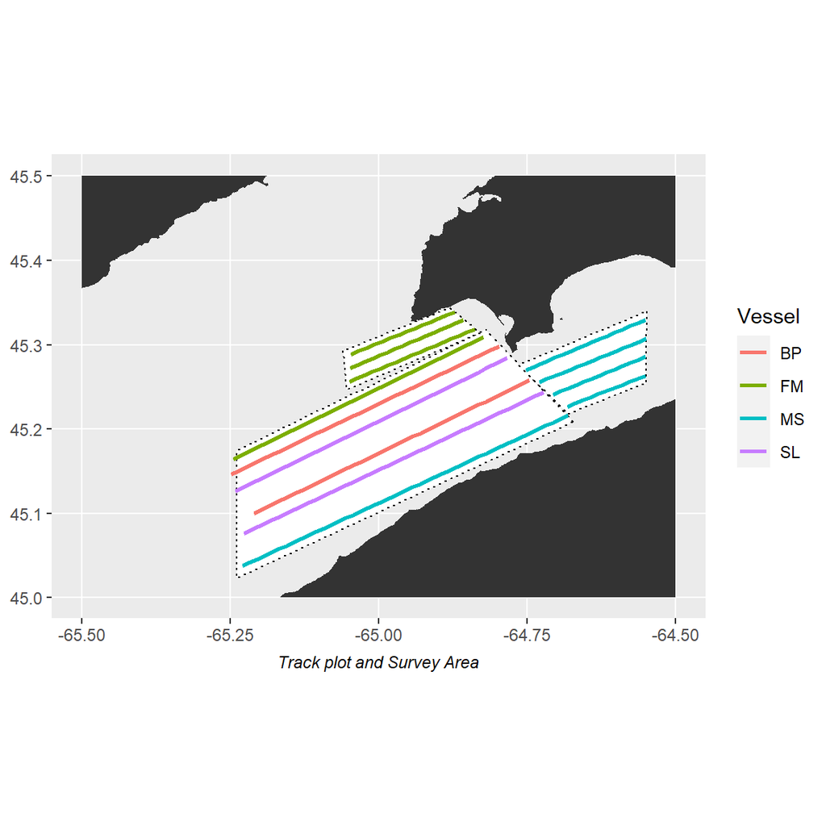

4 commercial purse seiners conducted this non-fishing survey on 22/05/2023 starting at 21:00:00.

There was a plankton tow and replicate conducted by Sealife II.

No tags were applied during this survey.

Since no fish were caught, no samples were obtained for target strength estimation.

### Tides Tables

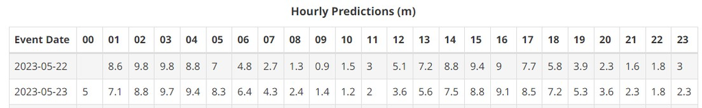

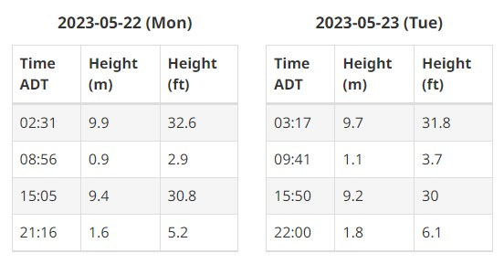

Tide Schedule for Margaretsville NS, Station #315, Source: www.waterlevels.gc.ca

### Acoustic Equipment

Each vessel was equipped with a Simrad ES38-18/200-18C combi (2-in-1) transducer prior to the survey that contains a 38kHz split beam and 200 kHz single beam transducer. Data was logged to the computer hard-drive for post-processing. BP and FM were calibrated on 38kHz before the survey, while all NS vessels were uncalibrated.

## Survey Results

### Main Results

The results are subject to change as DFO will re-evaluate data editing, area estimation and apply a target strength.

**Preliminary biomass prediction for Scots Bay using standardized parallel transects is 40,856mt.**

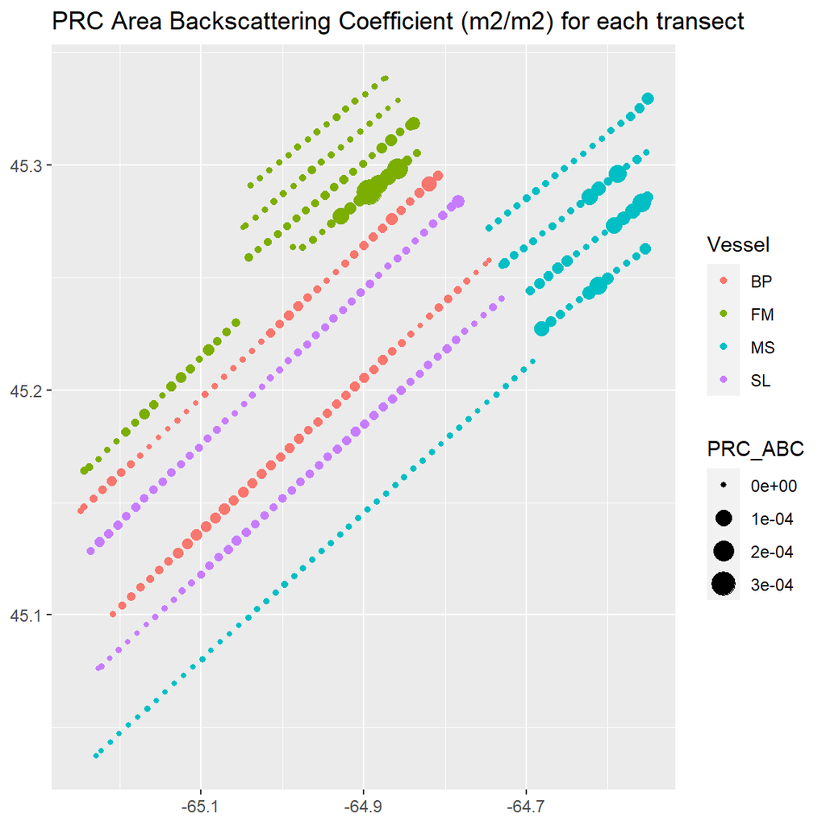

### Transect Details

Table 1: Transect Details

| Vessel | Transect # | Date/Time Start | Date/Time End | Start Lon | Start Lat | End Lon | End Lat | Location | Distance (km) | Speed |
| --- | --- | --- | --- | --- | --- | --- | --- | --- | --- | --- |
| BP | T02 | 2023-05-23 05:01:46 | 2023-05-23 07:49:27 | -64.746 | 45.258 | -65.210 | 45.100 | SB | 40.49 | 7.82 |
| BP | T01 | 2023-05-23 01:56:13 | 2023-05-23 04:35:30 | -65.249 | 45.146 | -64.798 | 45.298 | SB | 39.28 | 7.99 |
| FM | T01 | 2023-05-24 01:58:02 | 2023-05-24 04:23:07 | -65.245 | 45.164 | -64.824 | 45.309 | SB | 37.51 | 8.38 |
| FM | T02 | 2023-05-24 04:29:57 | 2023-05-24 05:45:15 | -64.839 | 45.319 | -65.050 | 45.256 | SB | 18.11 | 7.79 |
| FM | T03 | 2023-05-24 05:51:17 | 2023-05-24 06:44:17 | -65.049 | 45.272 | -64.857 | 45.330 | SB | 16.39 | 10.02 |
| FM | T04 | 2023-05-24 06:50:19 | 2023-05-24 07:46:14 | -64.872 | 45.339 | -65.048 | 45.289 | SB | 14.88 | 8.62 |
| MS | T01 | 2023-05-23 01:15:00 | 2023-05-23 04:04:46 | -65.230 | 45.037 | -64.681 | 45.216 | SB | 48.54 | 9.26 |
| MS | T02 | 2023-05-23 04:19:05 | 2023-05-23 05:01:55 | -64.683 | 45.227 | -64.551 | 45.263 | SB | 11.36 | 8.59 |
| MS | T03 | 2023-05-23 05:15:40 | 2023-05-23 06:16:53 | -64.551 | 45.286 | -64.707 | 45.241 | SB | 13.66 | 7.23 |
| MS | T04 | 2023-05-23 06:30:52 | 2023-05-23 07:27:37 | -64.730 | 45.256 | -64.550 | 45.307 | SB | 15.57 | 8.89 |
| MS | T05 | 2023-05-23 07:36:19 | 2023-05-23 08:40:18 | -64.551 | 45.330 | -64.753 | 45.270 | SB | 17.58 | 8.90 |
| SL | T01 | 2023-05-23 02:17:36 | 2023-05-23 05:06:51 | -65.227 | 45.076 | -64.722 | 45.244 | SB | 45.22 | 8.66 |
| SL | T02 | 2023-05-23 05:40:08 | 2023-05-23 08:19:31 | -64.784 | 45.284 | -65.242 | 45.126 | SB | 41.28 | 8.39 |

### Survey Summary

Table 2: Acoustic Survey Results

| Vessel | Transect No. | Target Strength (db/kg) | Mean Sa (/m2) | Biomass Density (kg/m2) |
| --- | --- | --- | --- | --- |
| MS | T03 | -35.5 | -43.945 | 0.143 |
| FM | T01 | -35.5 | -44.084 | 0.139 |
| MS | T02 | -35.5 | -44.573 | 0.124 |
| MS | T04 | -35.5 | -45.989 | 0.089 |
| FM | T02 | -35.5 | -48.753 | 0.047 |
| BP | T02 | -35.5 | -49.079 | 0.044 |
| BP | T01 | -35.5 | -50.240 | 0.034 |
| SL | T02 | -35.5 | -51.130 | 0.027 |
| SL | T01 | -35.5 | -51.640 | 0.024 |
| MS | T05 | -35.5 | -52.128 | 0.022 |
| FM | T03 | -35.5 | -57.601 | 0.006 |
| FM | T04 | -35.5 | -57.818 | 0.006 |
| MS | T01 | -35.5 | -62.645 | 0.002 |

Note:  
Transects are listed from greatest to least backscatter.

Table 3: Survey Summary Table

| Layer | Target Strength | Area (km2) | Mean Sa | Density (kg/m2) | Biomass (tons) | Percent Area | Percent Biomass | Standard Error (tons) | Standard Error (%) |
| --- | --- | --- | --- | --- | --- | --- | --- | --- | --- |
| Main Box | -35.5 | 664 | -49.2604 | 0.0449 | 27,933.451 | 76.1 | 68.4 | 12,988.27 | 46.50 |
| Northern Box | -35.5 | 81 | -52.2455 | 0.0198 | 1,713.703 | 9.3 | 4.2 | 1,114.24 | 65.02 |
| Eastern Box | -35.5 | 127 | -46.0424 | 0.0945 | 11,208.873 | 14.6 | 27.4 | 3,387.21 | 30.22 |

### Greatest Backscatter

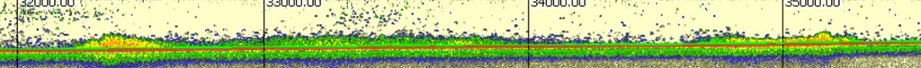

The single point with the greatest backscatter

The single point with the largest backscatter density (PRC) was recorded by **FM**, at the following location:

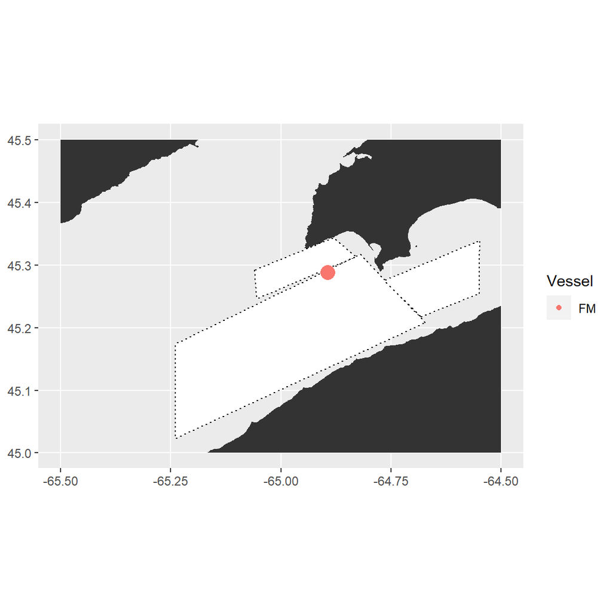

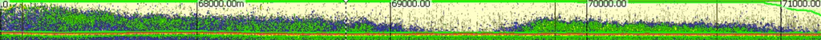

A snip from the transect with the greatest backscatter

The transect with the overall largest biomass was recorded by **MS**, at the following location:

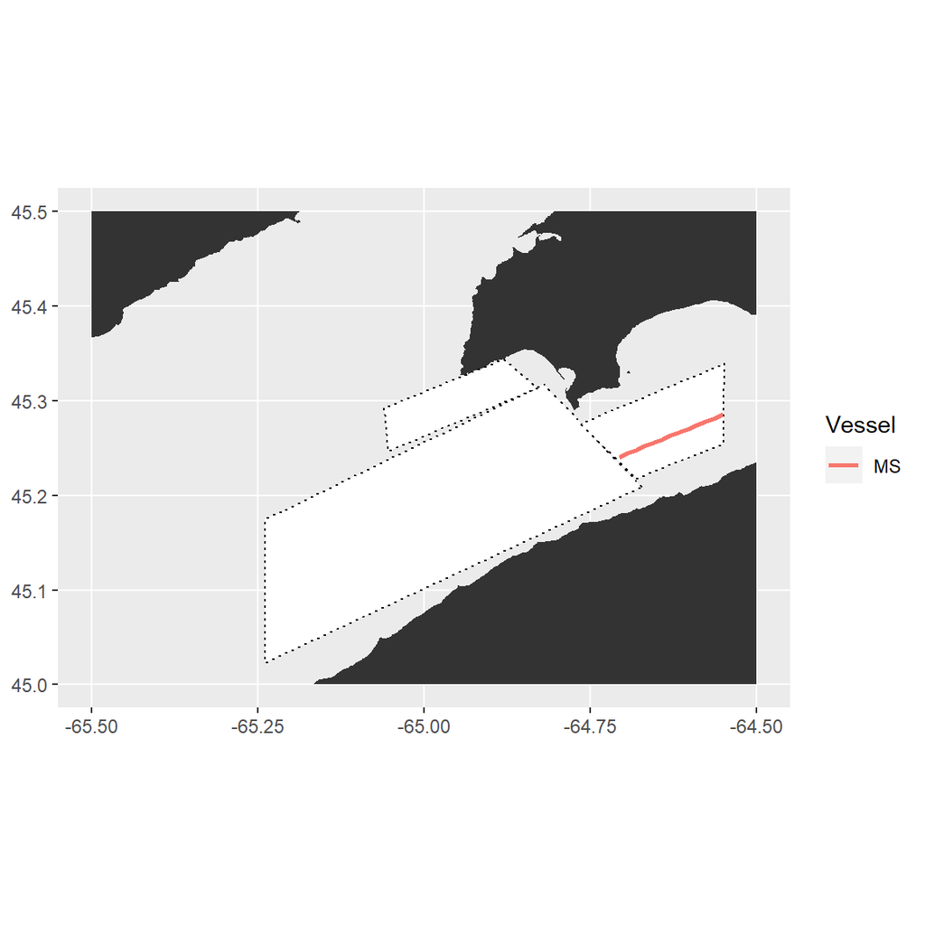

### Annual Summaries

Table 4: Annual Comparison Table

| Ground | Survey Number | Current Year Survey Date | Current Year HSC Estimate | Current Year HSC Turnover Adjusted | Previous Year Survey Date | Previous Year HSC Estimate | Previous Year HSC Turnover Adjusted | Previous Year DFO Estimate | Previous Year DFO Turnover Adjusted |
| --- | --- | --- | --- | --- | --- | --- | --- | --- | --- |
| Scots Bay | 1 | 2023-05-22 | 40,856 | 40,856 | 2022-05-29 | 90,746 | 90,746 | 99,092 | 99,092 |
| Scots Bay | 2 | NA | NA | NA | 2022-06-12 | 104,368 | 92,111 | 113,792 | 100,407 |
| Scots Bay | 3 | NA | NA | NA | 2022-06-26 | 34,199 | 19,781 | 29,429 | 13,709 |
| Scots Bay | 4 | NA | NA | NA | 2022-07-10 | 10,537 | 5,549 | 7,892 | 3,515 |
| Scots Bay | 5 | NA | NA | NA | 2022-07-26 | 13,060 | 11,904 | 11,402 | 10,536 |
| Scots Bay | 6 | NA | NA | NA | 2022-08-07 | 5,250 | 3,067 | 6,150 | 4,248 |
| Scots Bay | 7 | NA | NA | NA | 2022-08-21 | 4,392 | 3,453 | 4,688 | 3,656 |
| Scots Bay | 8 | NA | NA | NA | 2022-09-05 | 21,908 | 21,372 | 21,420 | 20,848 |
| Scots Bay | 9 | NA | NA | NA | 2022-09-18 | 8,133 | 4,850 | 7,283 | 0 |
| Scots Bay | 10 | NA | NA | NA | 2022-10-03 | NA | NA | 4,152 | 0 |

Table 5: Annual Summary Table

| Year | Ground | HSC Estimate | HSC Turnover Adjusted | DFO Estimate | DFO Turnover Adjusted |
| --- | --- | --- | --- | --- | --- |
| 2022 | Scots Bay | NA | NA | 305,300 | 256,011 |
| 2023 | Scots Bay | 40,856 | 40,856 | NA | NA |

## Tagging, Plankton, and CTD Data

### Tag Data

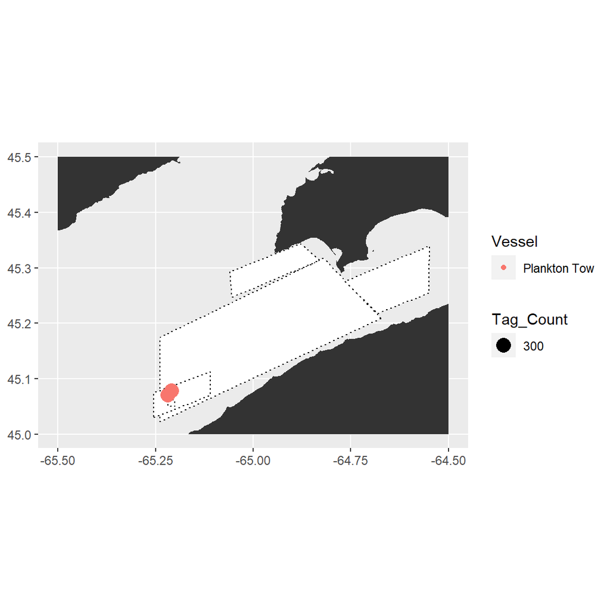

| Vessel | Tags |
| --- | --- |

### Plankton Data

#### Tow Summary Table

|  | Tow 1 | Tow 2 |
| --- | --- | --- |
| **Base Details** |  |  |
| Vessel | Sealife II | Sealife II |
| Set Number | SB2023-01 | SB2023-02 |
| Ground | SB | SB |
| Date | 22/05/2023 | 22/05/2023 |
| Wind Direction (km/h) | N | N |
| Swell (m) | 0.25 | 0.25 |
| Air Temp (c) | 5 | 5 |
| **Tow Details** |  |  |
| Tow Start | 04:05:00 | 04:25:00 |
| Tow End | 04:15:00 | 04:35:00 |
| Start Lat | 45.07833 | 45.07000 |
| End Lat | 45.07667 | 45.06833 |
| Start Lon | -65.20833 | -65.21833 |
| End Lon | -65.210 | -65.225 |
| Avg Tow Depth (m) | NA | NA |
| Speed | 2.5 | 2.5 |
| Heading | 270 | 60 |
| Tide Direction | with | against |
| **Other Data Collection** |  |  |
| Flow Start | 273230 | 297875 |
| Flow End | 297875 | 316516 |
| No. Revolutions | 24645 | 18641 |
| Distance (m) | 662.2851 | 500.9396 |
| Volume | 2080.569 | 1573.702 |
| Secchi Disappear (m) | 9 | 9 |
| Secchi Reappear (m) | 8 | 8 |

#### Captured plankton

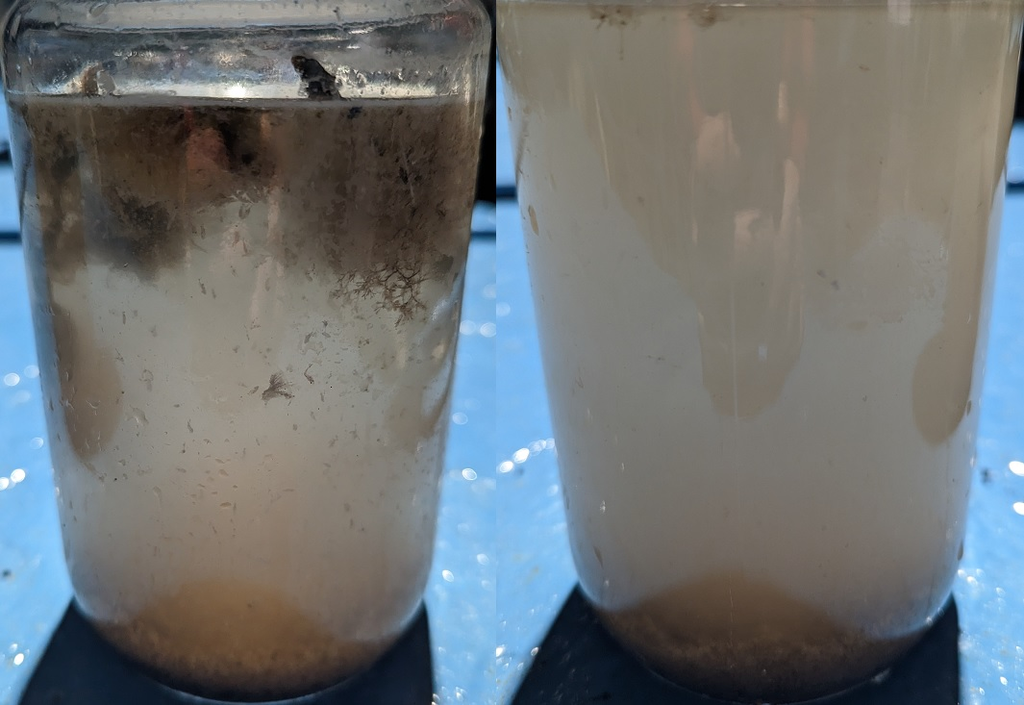

Captured plankton from the surface tows

### CTD Data

[figure not shown]

CTD depth profiles for all 2023 Scots Bay surveys so far.

#### Sea surface temperatures

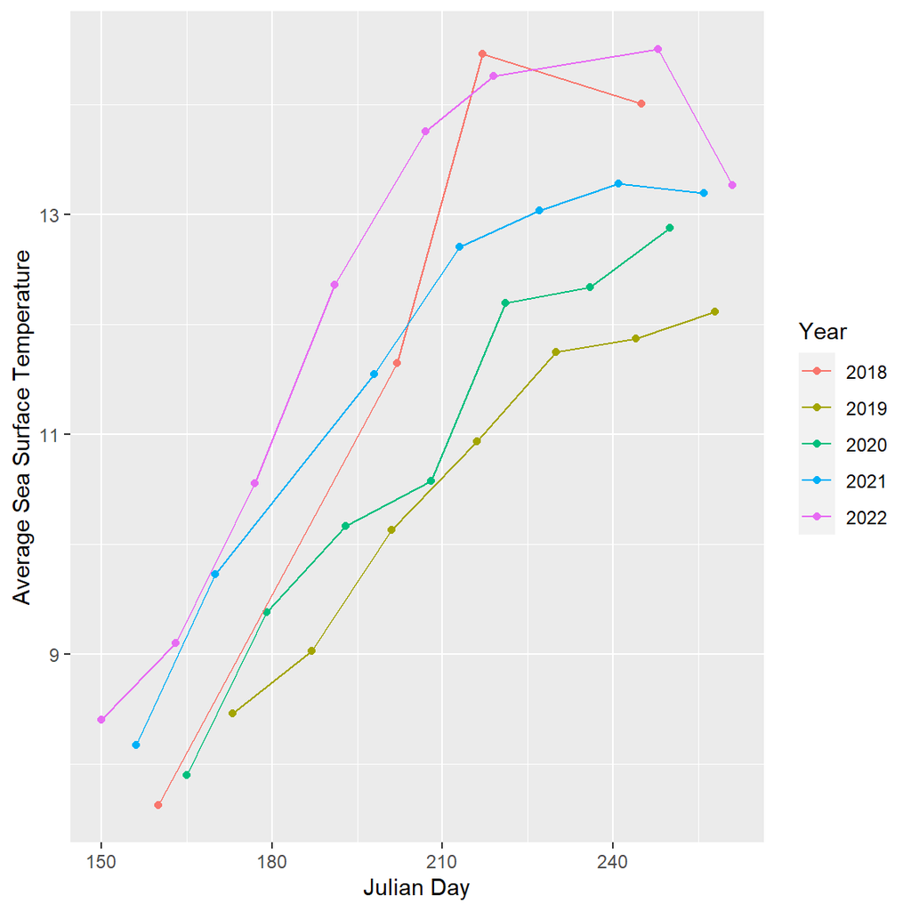

Annual average sea surface temperatures (SST) for Scots Bay.

## Vessel Performance

### Speed

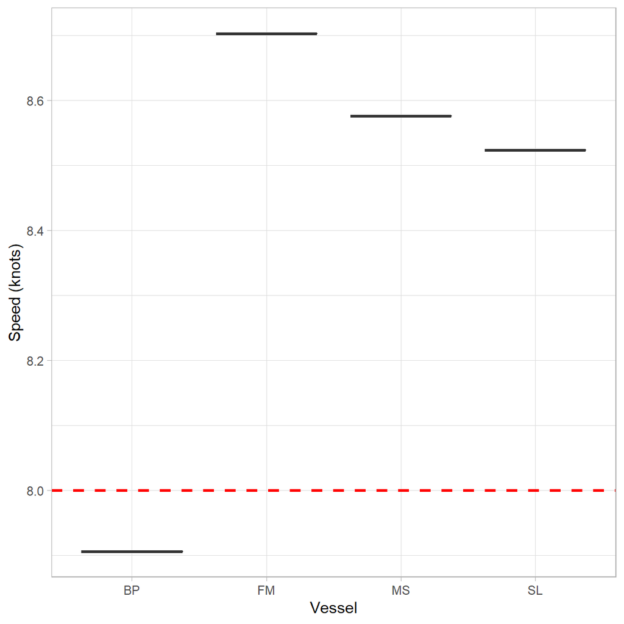

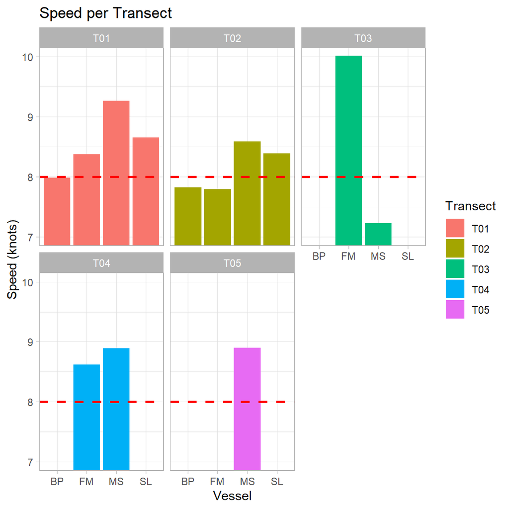

Average vessel speed was 8.43. This is above the 8 knot requirement; vessels are urged to slow down to prevent backscatter noise from interfering with the acoustic data.

### Distance

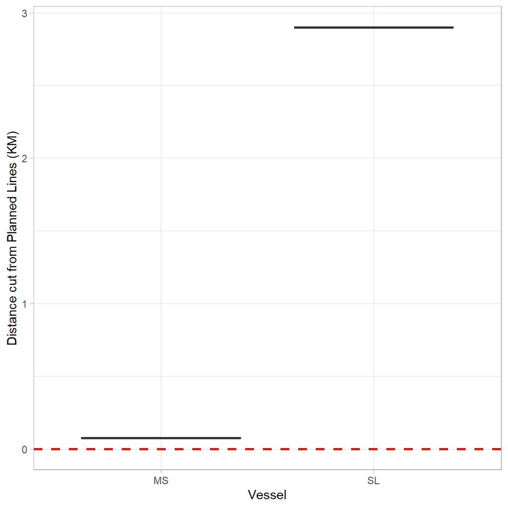

More than 2km of distance was cut from the planned lines; vessels are reminded to complete their assigned lines straight and without deviating or cutting corners short.